# Assignment 2, Part C

Carter Fitzgerald

2023-10-14

# Part C - Insights (17 marks)

**Perform the following tasks**

1. There is a claim that the climate-change phenomenon has been hitting the ACT region over the last 4 years. Using the `act_weather_data`, can you help the authorities validate whether this claim is correct or not? (6 marks)
- ( *hint:* This is an open question, where the claim can be checked and validated via different ways. Please explain your strategy and final insights with evidences (i.e., graphs). You may search for extra data from the public repository to support your final thoughts. )

```r
library(tidyverse)
library(dplyr)
library(Metrics)
library(modeest)
library(hms)
act_weather_data <- read_csv("act_weather_data_partA.csv")
act_weather_last_4_years <- act_weather_data %>%
  filter((Year >= 2019 & Month >= 4) | (Year > 2019) | (Year == 2019 & Month == 3))

# Group the data by Year and Month
monthly_summary <- act_weather_last_4_years %>%
  group_by(Year, Month) %>%
  summarise(
    Avg_Temperature = mean(`3pm_Temperature`, na.rm = TRUE),
    Avg_Rainfall = mean(`Rainfall_(mm)`, na.rm = TRUE)
  )
```

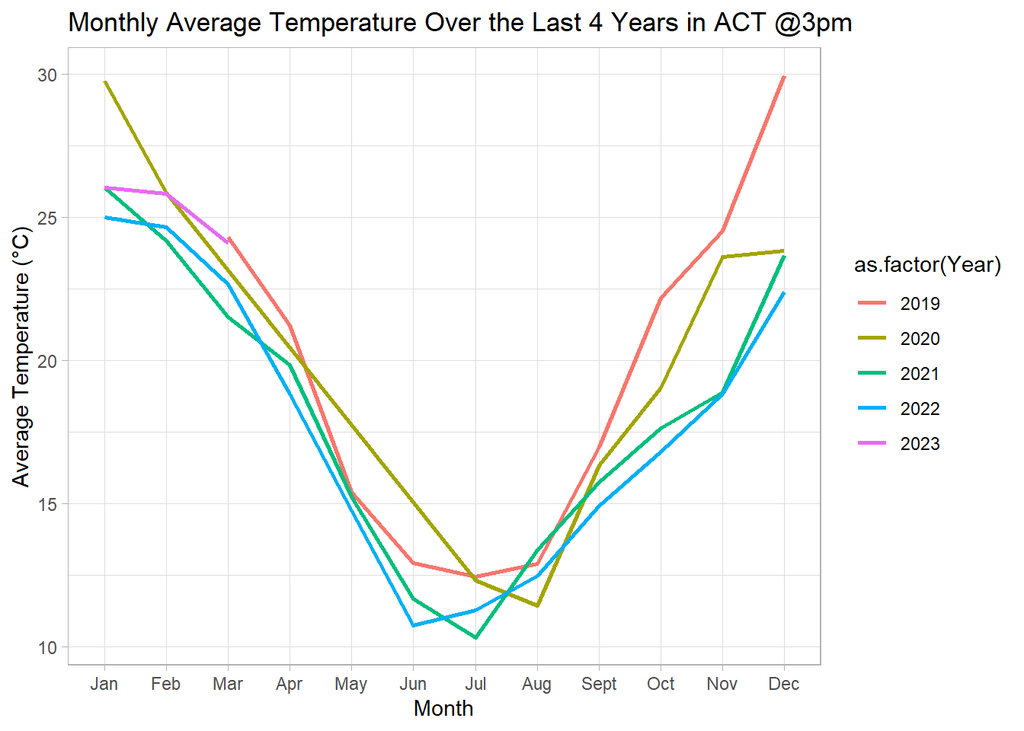

```r
yearly_summary <- monthly_summary %>%
  group_by(Year) %>%
  summarise(Avg_Temperature = mean(Avg_Temperature, na.rm = TRUE))

# Create a matrix with years as columns, to display average temp
yearly_matrix <- yearly_summary %>%
  pivot_wider(names_from = Year, values_from = Avg_Temperature)


month_order <- c("Jan", "Feb", "Mar", "Apr", "May", "Jun", "Jul", "Aug", "Sept", "Oct", "Nov", "Dec")

# Create graph for monthly avg temp
temperature_monthly_plot <- ggplot(monthly_summary, aes(x = Month, y = Avg_Temperature, color = as.factor(Year))) +
  geom_path(size = 1) +
  labs(title = "Monthly Average Temperature Over the Last 4 Years in ACT @3pm",
       x = "Month",
       y = "Average Temperature (°C)") +
  scale_x_discrete(limits = month_order) +
  theme_light()
print(temperature_monthly_plot)
```

```r
cat("Yearly Average Temperatures\n")
```

```
## Yearly Average Temperatures
```

```r
print(yearly_matrix)
```

```
## # A tibble: 1 × 5
##   `2019` `2020` `2021` `2022` `2023`
##    <dbl>  <dbl>  <dbl>  <dbl>  <dbl>
## 1   19.3   20.3   18.2   17.8   25.3
```

2. The ACT Transport Sector is seeking to use this data to understand when the ACT road construction should be going ahead and when it should be stopped. Also, the sector plans to build a time plan over the year to fix potholes after rain seasons, can you help them building analysis of which times in the year that this would be perfect? (6 marks)

```r
monthly_summary_2 <- act_weather_data %>%
  group_by(Year, Month) %>%
  summarise(
    Avg_Temperature = mean(`3pm_Temperature`, na.rm = TRUE),
    Avg_Rainfall = mean(`Rainfall_(mm)`, na.rm = TRUE)
  )
```

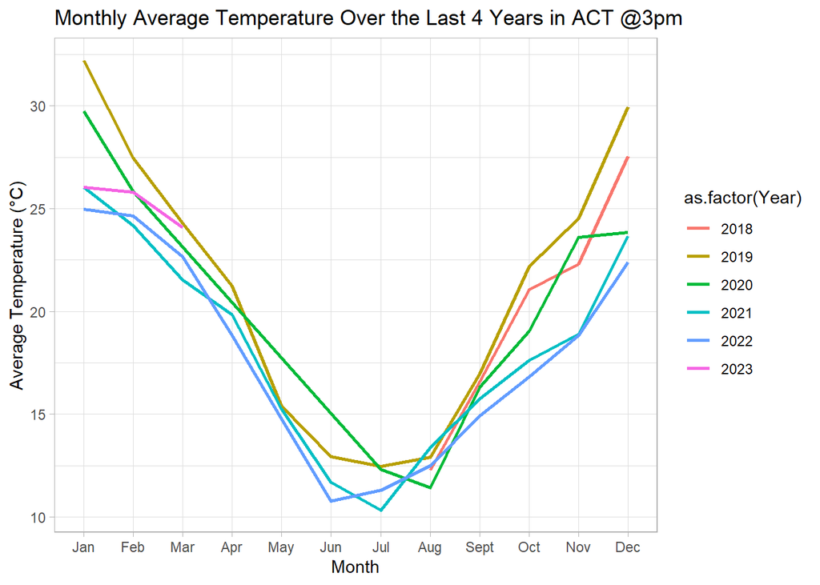

```r
month_order <- c("Jan", "Feb", "Mar", "Apr", "May", "Jun", "Jul", "Aug", "Sept", "Oct", "Nov", "Dec")

# Create graph for monthly avg temp
temperature_monthly_plot <- ggplot(monthly_summary_2, aes(x = Month, y = Avg_Temperature, color = as.factor(Year))) +
  geom_path(size = 1) +
  labs(title = "Monthly Average Temperature Over the Last 4 Years in ACT @3pm",
       x = "Month",
       y = "Average Temperature (°C)") +
  scale_x_discrete(limits = month_order) +
  theme_light()

# Create graph for monthly avg rainfall
rainfall_monthly_plot <- ggplot(monthly_summary_2, aes(x = Month, y = Avg_Rainfall, color = as.factor(Year))) +
  geom_path(size = 1) +
  labs(title = "Monthly Average Rainfall Over the Last 4 Years in ACT @3pm",
       x = "Month",
       y = "Average Rainfall (mm)") +
  scale_x_discrete(limits = month_order) +
  theme_light()

monthly_summary_2 <- monthly_summary_2 %>%
  mutate(Date = as.Date(paste(Year, Month, "01", sep = "-")))

# Create time series objects
ts_data <- ts(monthly_summary_2$Avg_Temperature, frequency = 12, start = c(2019, 1))
ts_data_1 <- ts(monthly_summary_2$Avg_Rainfall, frequency = 12, start = c(2019, 1))

# Perform seasonal decomposition
decomposed <- decompose(ts_data)
decomposed_rain <- decompose(ts_data_1)

monthly_summary_2 <- monthly_summary_2 %>%
  mutate(Combined_Score = Avg_Temperature - 2 * Avg_Rainfall)

# Summarize the scores for each month across all years
monthly_summary_summary <- monthly_summary_2 %>%
  group_by(Month) %>%
  summarise(Avg_Score = mean(Combined_Score))

# Identify the top four months with the highest scores
top_months <- monthly_summary_summary %>%
  arrange(desc(Avg_Score)) %>%
  head(4)

print(temperature_monthly_plot)
```